# Reproducible Research: Peer Assessment 1

**Written By: Mike Silva**

In this analysis I will answer the following questions:  
1. What is mean total number of steps taken per day?  
2. What is the average daily activity pattern?  
3. Are there differences in activity patterns between weekdays and weekends?

## Loading and preprocessing the data

First we check for the zip archive in the working directory. If it is not there, it is downloaded. The data is loaded into the environment.

```r
temp <- "activity.zip"
if(!file.exists(temp)){
  download.file("http://d396qusza40orc.cloudfront.net/repdata%2Fdata%2Factivity.zip",temp)
}
data <- read.csv(unz(temp, "activity.csv"))
```

Now that we have the data let’s check the structure:

```r
str(data)
```

```
## 'data.frame':    17568 obs. of  3 variables:
##  $ steps   : int  NA NA NA NA NA NA NA NA NA NA ...
##  $ date    : Factor w/ 61 levels "2012-10-01","2012-10-02",..: 1 1 1 1 1 1 1 1 1 1 ...
##  $ interval: int  0 5 10 15 20 25 30 35 40 45 ...
```

The “date” variable is a factor instead of a date. We need to change the type.

```r
data$date <- as.Date(data$date, "%Y-%m-%d");
```

Checking the structure once again we see:

```r
str(data)
```

```
## 'data.frame':    17568 obs. of  3 variables:
##  $ steps   : int  NA NA NA NA NA NA NA NA NA NA ...
##  $ date    : Date, format: "2012-10-01" "2012-10-01" ...
##  $ interval: int  0 5 10 15 20 25 30 35 40 45 ...
```

“Date” is now a date. Finally we will load the data into a data table object.

```r
library(data.table)
data <- as.data.table(data)
```

## What is mean total number of steps taken per day?

To answer this question we must first aggregate the data by the date.

```r
data.by.date <- data[,sum(steps), by="date"]
setnames(data.by.date, "V1" ,"steps")
```

The following figure illustrates the distribution of the total number of steps taken each day. The dashed red line represents the mean.

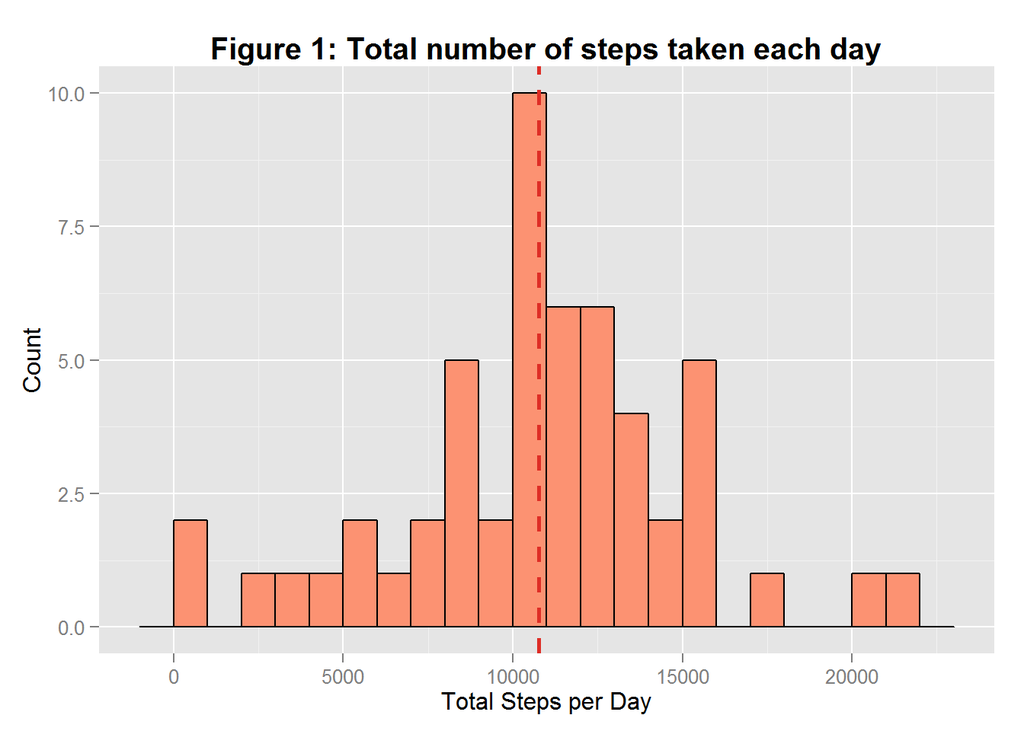

```r
library(ggplot2)
ggplot(data.by.date, aes(x=steps)) + geom_histogram(colour="black", fill="#fc9272", binwidth=1000) + geom_vline(aes(xintercept=mean(steps, na.rm=T)), color="#de2d26", linetype="dashed", size=1) + ggtitle("Figure 1: Total number of steps taken each day") + xlab("Total Steps per Day") + ylab("Count") + theme(plot.title=element_text(size=rel(1.25), lineheight=2, face="bold"))
```

The mean and median total number of steps taken per day are **10,766** and **10,765** respectively as computed below:

```r
mean(data.by.date$steps, na.rm=T)
```

```
## [1] 10766
```

```r
median(data.by.date$steps, na.rm=T)
```

```
## [1] 10765
```

## What is the average daily activity pattern?

To explore this question we first have to aggregate the data by 5-minute intervals.

```r
data.by.interval <- data[,mean(steps, na.rm=T), by="interval"]
setnames(data.by.interval,"V1","avg.steps")
```

We then created a time series plot to visualize the data:

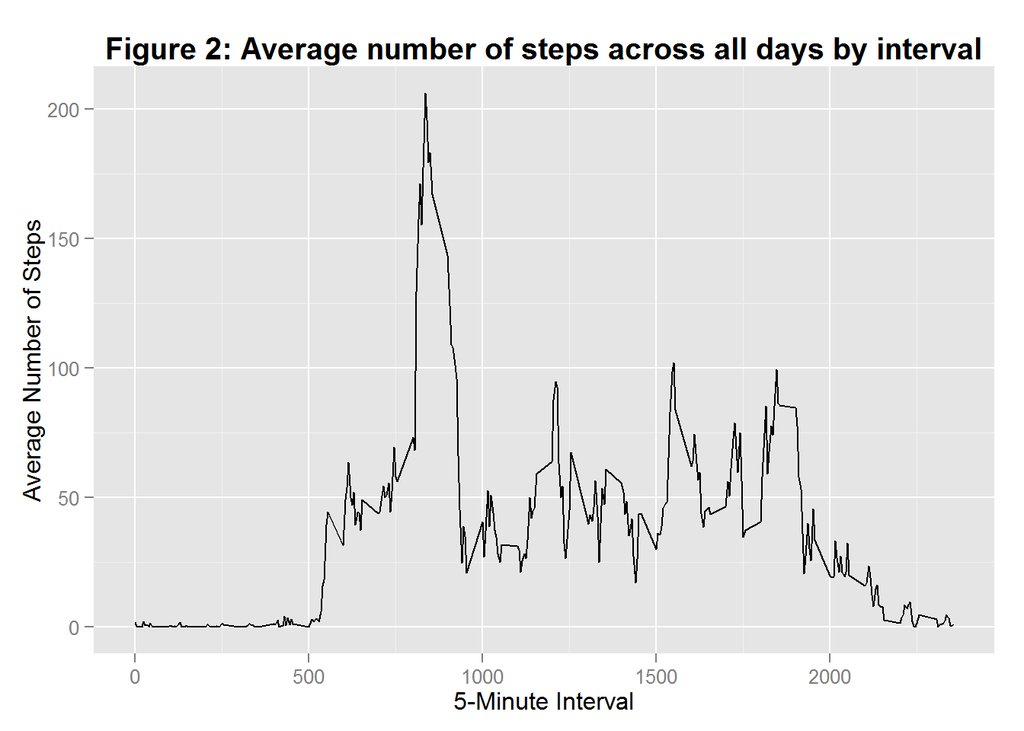

```r
ggplot(data=data.by.interval, aes(x=interval, y=avg.steps)) + geom_line() + xlab("5-Minute Interval") + ylab("Average Number of Steps") + ggtitle("Figure 2: Average number of steps across all days by interval") + theme(plot.title=element_text(size=rel(1.25), lineheight=2, face="bold"))
```

We see that there are very few steps util about the 500th 5-minute interval. The peak is somewhere around 800.

### Which 5-minute interval, on average across all the days in the data set, contains the maximum number of steps?

To get a more precise answer we subset the data by interval pulling out the observation with the maximum average steps:

```r
data.by.interval[data.by.interval$avg.steps == max(data.by.interval$avg.steps),]
```

```
##    interval avg.steps
## 1:      835     206.2
```

Interval **835** had the maximum number of steps (about 206).

## Imputing missing values

When observing the data there are a number of days/intervals where there are missing values (coded as NA).

```r
summary(data$steps)
```

```
##    Min. 1st Qu.  Median    Mean 3rd Qu.    Max.    NA's
##     0.0     0.0     0.0    37.4    12.0   806.0    2304
```

**2,304** observations are missing data. I will fill in these observations with the mean number of steps for the given 5 minute interval.

```r
library(plyr)
impute.mean <- function(x) replace(x, is.na(x), mean(x, na.rm = TRUE))
imputed.data <- ddply(data, ~ interval, transform, steps = impute.mean(steps))
```

Now we check to see if there are no NA’s

```r
summary(imputed.data$steps)
```

```
##    Min. 1st Qu.  Median    Mean 3rd Qu.    Max.
##     0.0     0.0     0.0    37.4    27.0   806.0
```

Now we want to see a histogram of the total number of steps taken each day. To do this we need to first aggregate the data by date:

```r
imputed.data <- as.data.table(imputed.data)
imputed.data.by.date <- imputed.data[,sum(steps), by="date"]
setnames(imputed.data.by.date, "V1" ,"steps")
```

Now we can plot the histogram. This time it is in blue and the dashed blue line represents the mean:

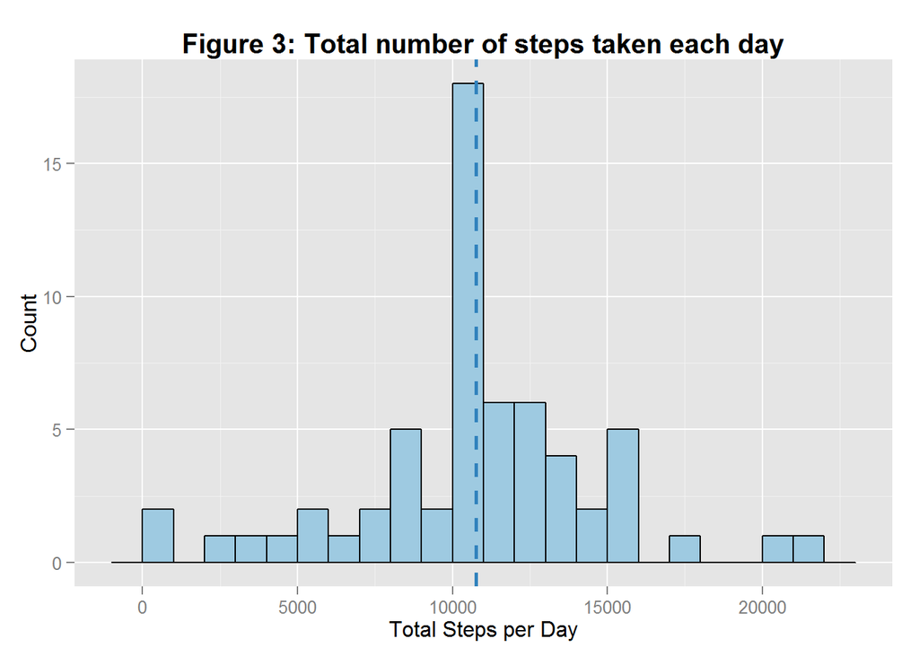

```r
ggplot(imputed.data.by.date, aes(x=steps)) + geom_histogram(colour="black", fill="#9ecae1", binwidth=1000) + geom_vline(aes(xintercept=mean(steps, na.rm=T)), color="#3182bd", linetype="dashed", size=1) + ggtitle("Figure 3: Total number of steps taken each day") + xlab("Total Steps per Day") + ylab("Count") + theme(plot.title=element_text(size=rel(1.25), lineheight=2, face="bold"))
```

### Do these values differ from the first estimates?

As you may recall the mean and median total number of steps taken per day, without imputation, are **10,766** and **10,765** respectively. Once the missing data was filled with imputed values the mean and median total number of steps taken per day, are **both 10,766**

```r
mean(imputed.data.by.date$steps)
```

```
## [1] 10766
```

```r
median(imputed.data.by.date$steps)
```

```
## [1] 10766
```

So do these values differ? The answer is no for the mean and yes for the median.

### What is the impact of imputing missing data on the estimates of the total daily number of steps?

By imputing values using the mean, we are reinforced the trends that existed in the data. This is observed when overlaying the two histograms:

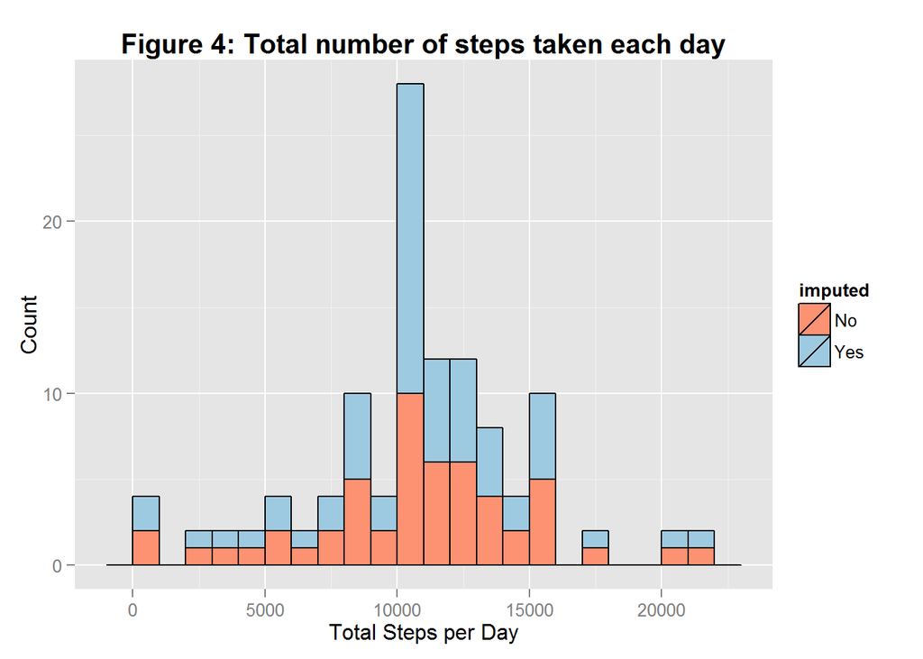

```r
data.by.date$imputed <- "No"
imputed.data.by.date$imputed <- "Yes"
histogram.data <- rbind(data.by.date, imputed.data.by.date)
ggplot(histogram.data, aes(x=steps, fill=imputed)) + geom_histogram(colour="black", binwidth=1000)+scale_fill_manual(values=c("#fc9272", "#9ecae1"))+ ggtitle("Figure 4: Total number of steps taken each day") + xlab("Total Steps per Day") + ylab("Count") + theme(plot.title=element_text(size=rel(1.25), lineheight=2, face="bold"))
```

## Are there differences in activity patterns between weekdays and weekends?

We will be using the data set with imputed values for this analysis. First we determine if the day was a weekday or a weekend:

```r
imputed.data$day.of.week <- 'Weekday'
imputed.data[weekdays(imputed.data$date)=="Sunday" | weekdays(imputed.data$date)=="Saturday",4] <- 'Weekend'

table(imputed.data$day.of.week)
```

```
##
## Weekday Weekend
##   12960    4608
```

There are 12,960 weekday and 4,608 weekend observations in the data set.  
To explore this question we first have to aggregate the data by 5-minute intervals.

```r
imputed.data.by.interval <- imputed.data[,mean(steps, na.rm=T), by="interval,day.of.week"]
setnames(imputed.data.by.interval,"V1","avg.steps")
```

We then created a time series plot to visualize the data:

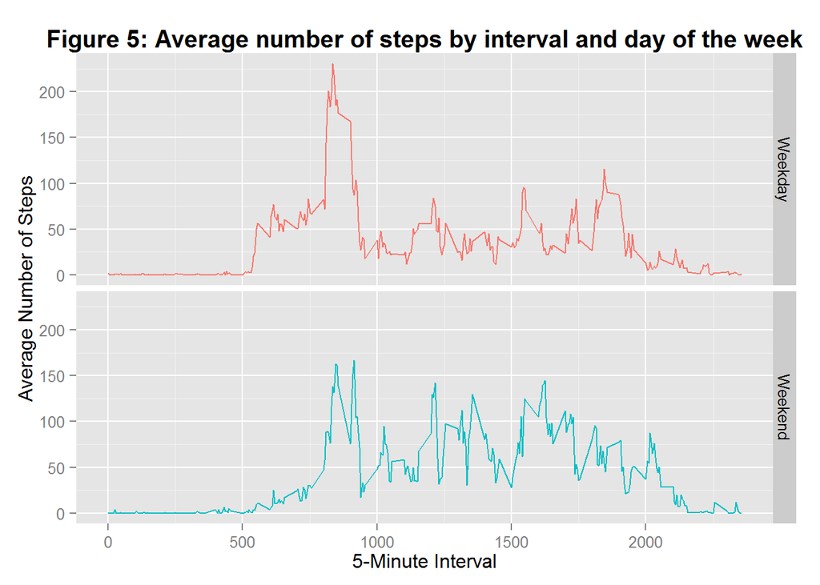

```r
ggplot(data=imputed.data.by.interval, aes(x=interval, y=avg.steps, color=day.of.week)) + geom_line() + facet_grid(day.of.week ~ .) + xlab("5-Minute Interval") + ylab("Average Number of Steps") + ggtitle("Figure 5: Average number of steps by interval and day of the week") + theme(plot.title=element_text(size=rel(1.25), lineheight=2, face="bold")) + guides(color=FALSE)
```

```r
by(imputed.data.by.interval$avg.steps, imputed.data.by.interval$day.of.week, summary)
```

```
## imputed.data.by.interval$day.of.week: Weekday
##    Min. 1st Qu.  Median    Mean 3rd Qu.    Max.
##    0.00    2.25   25.80   35.60   50.90  230.00
## --------------------------------------------------------
## imputed.data.by.interval$day.of.week: Weekend
##    Min. 1st Qu.  Median    Mean 3rd Qu.    Max.
##    0.00    1.24   32.30   42.40   74.70  167.00
```

The weekday average number of steps is about **36** while the weekend is about **42**.